# Churn_pred

#### Importing the libraries:

```python
#import req libs:
import pandas as pd
import numpy as np
import matplotlib.pyplot as plt
import seaborn as sns
%matplotlib inline
```

#### Acquring the data:

```python
#Read the data sets:
train=pd.read_csv('churn-bigml-train.csv')
test=pd.read_csv('churn-bigml-test.csv')
print(train.shape) #to know the shape of train data
print(test.shape) #to know the shape of test data
```

```
(2666, 20)
(667, 20)
```

```python
train.head() #displaying the train head
```

|  | State | Account length | Area code | International plan | Voice mail plan | Number vmail messages | Total day minutes | Total day calls | Total day charge | Total eve minutes | Total eve calls | Total eve charge | Total night minutes | Total night calls | Total night charge | Total intl minutes | Total intl calls | Total intl charge | Customer service calls | Churn |
| --- | --- | --- | --- | --- | --- | --- | --- | --- | --- | --- | --- | --- | --- | --- | --- | --- | --- | --- | --- | --- |
| 0 | KS | 128 | 415 | No | Yes | 25 | 265.1 | 110 | 45.07 | 197.4 | 99 | 16.78 | 244.7 | 91 | 11.01 | 10.0 | 3 | 2.70 | 1 | False |
| 1 | OH | 107 | 415 | No | Yes | 26 | 161.6 | 123 | 27.47 | 195.5 | 103 | 16.62 | 254.4 | 103 | 11.45 | 13.7 | 3 | 3.70 | 1 | False |
| 2 | NJ | 137 | 415 | No | No | 0 | 243.4 | 114 | 41.38 | 121.2 | 110 | 10.30 | 162.6 | 104 | 7.32 | 12.2 | 5 | 3.29 | 0 | False |
| 3 | OH | 84 | 408 | Yes | No | 0 | 299.4 | 71 | 50.90 | 61.9 | 88 | 5.26 | 196.9 | 89 | 8.86 | 6.6 | 7 | 1.78 | 2 | False |
| 4 | OK | 75 | 415 | Yes | No | 0 | 166.7 | 113 | 28.34 | 148.3 | 122 | 12.61 | 186.9 | 121 | 8.41 | 10.1 | 3 | 2.73 | 3 | False |

```python
train.dtypes
```

```
State                      object
Account length              int64
Area code                   int64
International plan         object
Voice mail plan            object
Number vmail messages       int64
Total day minutes         float64
Total day calls             int64
Total day charge          float64
Total eve minutes         float64
Total eve calls             int64
Total eve charge          float64
Total night minutes       float64
Total night calls           int64
Total night charge        float64
Total intl minutes        float64
Total intl calls            int64
Total intl charge         float64
Customer service calls      int64
Churn                        bool
dtype: object
```

```python
test.head() #displaying test head
```

|  | State | Account length | Area code | International plan | Voice mail plan | Number vmail messages | Total day minutes | Total day calls | Total day charge | Total eve minutes | Total eve calls | Total eve charge | Total night minutes | Total night calls | Total night charge | Total intl minutes | Total intl calls | Total intl charge | Customer service calls | Churn |
| --- | --- | --- | --- | --- | --- | --- | --- | --- | --- | --- | --- | --- | --- | --- | --- | --- | --- | --- | --- | --- |
| 0 | LA | 117 | 408 | No | No | 0 | 184.5 | 97 | 31.37 | 351.6 | 80 | 29.89 | 215.8 | 90 | 9.71 | 8.7 | 4 | 2.35 | 1 | False |
| 1 | IN | 65 | 415 | No | No | 0 | 129.1 | 137 | 21.95 | 228.5 | 83 | 19.42 | 208.8 | 111 | 9.40 | 12.7 | 6 | 3.43 | 4 | True |
| 2 | NY | 161 | 415 | No | No | 0 | 332.9 | 67 | 56.59 | 317.8 | 97 | 27.01 | 160.6 | 128 | 7.23 | 5.4 | 9 | 1.46 | 4 | True |
| 3 | SC | 111 | 415 | No | No | 0 | 110.4 | 103 | 18.77 | 137.3 | 102 | 11.67 | 189.6 | 105 | 8.53 | 7.7 | 6 | 2.08 | 2 | False |
| 4 | HI | 49 | 510 | No | No | 0 | 119.3 | 117 | 20.28 | 215.1 | 109 | 18.28 | 178.7 | 90 | 8.04 | 11.1 | 1 | 3.00 | 1 | False |

#### Describing the data:

```python
train.describe()
```

|  | Account length | Area code | Number vmail messages | Total day minutes | Total day calls | Total day charge | Total eve minutes | Total eve calls | Total eve charge | Total night minutes | Total night calls | Total night charge | Total intl minutes | Total intl calls | Total intl charge | Customer service calls |
| --- | --- | --- | --- | --- | --- | --- | --- | --- | --- | --- | --- | --- | --- | --- | --- | --- |
| count | 2666.000000 | 2666.000000 | 2666.000000 | 2666.00000 | 2666.000000 | 2666.000000 | 2666.000000 | 2666.000000 | 2666.000000 | 2666.000000 | 2666.000000 | 2666.000000 | 2666.000000 | 2666.000000 | 2666.000000 | 2666.000000 |
| mean | 100.620405 | 437.438860 | 8.021755 | 179.48162 | 100.310203 | 30.512404 | 200.386159 | 100.023631 | 17.033072 | 201.168942 | 100.106152 | 9.052689 | 10.237022 | 4.467367 | 2.764490 | 1.562641 |
| std | 39.563974 | 42.521018 | 13.612277 | 54.21035 | 19.988162 | 9.215733 | 50.951515 | 20.161445 | 4.330864 | 50.780323 | 19.418459 | 2.285120 | 2.788349 | 2.456195 | 0.752812 | 1.311236 |
| min | 1.000000 | 408.000000 | 0.000000 | 0.00000 | 0.000000 | 0.000000 | 0.000000 | 0.000000 | 0.000000 | 43.700000 | 33.000000 | 1.970000 | 0.000000 | 0.000000 | 0.000000 | 0.000000 |
| 25% | 73.000000 | 408.000000 | 0.000000 | 143.40000 | 87.000000 | 24.380000 | 165.300000 | 87.000000 | 14.050000 | 166.925000 | 87.000000 | 7.512500 | 8.500000 | 3.000000 | 2.300000 | 1.000000 |
| 50% | 100.000000 | 415.000000 | 0.000000 | 179.95000 | 101.000000 | 30.590000 | 200.900000 | 100.000000 | 17.080000 | 201.150000 | 100.000000 | 9.050000 | 10.200000 | 4.000000 | 2.750000 | 1.000000 |
| 75% | 127.000000 | 510.000000 | 19.000000 | 215.90000 | 114.000000 | 36.700000 | 235.100000 | 114.000000 | 19.980000 | 236.475000 | 113.000000 | 10.640000 | 12.100000 | 6.000000 | 3.270000 | 2.000000 |
| max | 243.000000 | 510.000000 | 50.000000 | 350.80000 | 160.000000 | 59.640000 | 363.700000 | 170.000000 | 30.910000 | 395.000000 | 166.000000 | 17.770000 | 20.000000 | 20.000000 | 5.400000 | 9.000000 |

##### Here, we can drop the STATE and AREA CODE columns because, their values are isignificant in predicting the final output of our models, i.e., CHURN

#### In this dataset, we're going to consider all the values after droping the unnecessary columns and we consider CHURN as the output column

```python
train.drop(['Area code','State'],axis=1,inplace=True)
test.drop(['Area code','State'],axis=1,inplace=True)
```

```python
train.head() #displaying head after drop
```

|  | Account length | International plan | Voice mail plan | Number vmail messages | Total day minutes | Total day calls | Total day charge | Total eve minutes | Total eve calls | Total eve charge | Total night minutes | Total night calls | Total night charge | Total intl minutes | Total intl calls | Total intl charge | Customer service calls | Churn |
| --- | --- | --- | --- | --- | --- | --- | --- | --- | --- | --- | --- | --- | --- | --- | --- | --- | --- | --- |
| 0 | 128 | No | Yes | 25 | 265.1 | 110 | 45.07 | 197.4 | 99 | 16.78 | 244.7 | 91 | 11.01 | 10.0 | 3 | 2.70 | 1 | False |
| 1 | 107 | No | Yes | 26 | 161.6 | 123 | 27.47 | 195.5 | 103 | 16.62 | 254.4 | 103 | 11.45 | 13.7 | 3 | 3.70 | 1 | False |
| 2 | 137 | No | No | 0 | 243.4 | 114 | 41.38 | 121.2 | 110 | 10.30 | 162.6 | 104 | 7.32 | 12.2 | 5 | 3.29 | 0 | False |
| 3 | 84 | Yes | No | 0 | 299.4 | 71 | 50.90 | 61.9 | 88 | 5.26 | 196.9 | 89 | 8.86 | 6.6 | 7 | 1.78 | 2 | False |
| 4 | 75 | Yes | No | 0 | 166.7 | 113 | 28.34 | 148.3 | 122 | 12.61 | 186.9 | 121 | 8.41 | 10.1 | 3 | 2.73 | 3 | False |

### Checking for Null values:

```python
train.isnull().sum() #no null values in train
```

```
Account length            0
International plan        0
Voice mail plan           0
Number vmail messages     0
Total day minutes         0
Total day calls           0
Total day charge          0
Total eve minutes         0
Total eve calls           0
Total eve charge          0
Total night minutes       0
Total night calls         0
Total night charge        0
Total intl minutes        0
Total intl calls          0
Total intl charge         0
Customer service calls    0
Churn                     0
dtype: int64
```

```python
test.isnull().sum() #no null value in test
```

```
Account length            0
International plan        0
Voice mail plan           0
Number vmail messages     0
Total day minutes         0
Total day calls           0
Total day charge          0
Total eve minutes         0
Total eve calls           0
Total eve charge          0
Total night minutes       0
Total night calls         0
Total night charge        0
Total intl minutes        0
Total intl calls          0
Total intl charge         0
Customer service calls    0
Churn                     0
dtype: int64
```

```python
train.shape
```

```
(2666, 18)
```

## Visualizations:

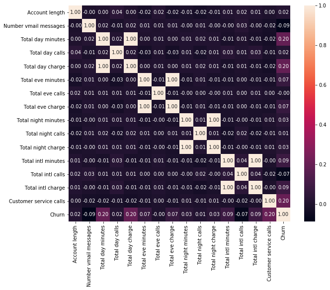

```python
plt.subplots(figsize=(10,8))
sns.heatmap(train.corr(),annot=True,fmt=".2f")
```

#### Therefore, it is feasible to drop one of these columns from the train and test data

```python
train.drop(["Number vmail messages","Total day minutes","Total eve minutes",\
                  "Total night minutes","Total intl minutes"],axis=1,inplace=True)
test.drop(["Number vmail messages","Total day minutes","Total eve minutes",\
                  "Total night minutes","Total intl minutes"],axis=1,inplace=True)
```

##### Encoding the data using label encoding:

```python
from sklearn.preprocessing import LabelEncoder
le = LabelEncoder()
#encoding international plan
train["International plan"]=le.fit_transform(train["International plan"])
test["International plan"]=le.fit_transform(test["International plan"])
#encoding voice mail plan
train["Voice mail plan"]=le.fit_transform(train["Voice mail plan"])
test["Voice mail plan"]=le.fit_transform(test["Voice mail plan"])
#encoding churn
train["Churn"]=le.fit_transform(train["Churn"])
test["Churn"]=le.fit_transform(test["Churn"])
train.head()
```

|  | Account length | International plan | Voice mail plan | Total day calls | Total day charge | Total eve calls | Total eve charge | Total night calls | Total night charge | Total intl calls | Total intl charge | Customer service calls | Churn |
| --- | --- | --- | --- | --- | --- | --- | --- | --- | --- | --- | --- | --- | --- |
| 0 | 128 | 0 | 1 | 110 | 45.07 | 99 | 16.78 | 91 | 11.01 | 3 | 2.70 | 1 | 0 |
| 1 | 107 | 0 | 1 | 123 | 27.47 | 103 | 16.62 | 103 | 11.45 | 3 | 3.70 | 1 | 0 |
| 2 | 137 | 0 | 0 | 114 | 41.38 | 110 | 10.30 | 104 | 7.32 | 5 | 3.29 | 0 | 0 |
| 3 | 84 | 1 | 0 | 71 | 50.90 | 88 | 5.26 | 89 | 8.86 | 7 | 1.78 | 2 | 0 |
| 4 | 75 | 1 | 0 | 113 | 28.34 | 122 | 12.61 | 121 | 8.41 | 3 | 2.73 | 3 | 0 |

```python
test.head()
```

|  | Account length | International plan | Voice mail plan | Total day calls | Total day charge | Total eve calls | Total eve charge | Total night calls | Total night charge | Total intl calls | Total intl charge | Customer service calls | Churn |
| --- | --- | --- | --- | --- | --- | --- | --- | --- | --- | --- | --- | --- | --- |
| 0 | 117 | 0 | 0 | 97 | 31.37 | 80 | 29.89 | 90 | 9.71 | 4 | 2.35 | 1 | 0 |
| 1 | 65 | 0 | 0 | 137 | 21.95 | 83 | 19.42 | 111 | 9.40 | 6 | 3.43 | 4 | 1 |
| 2 | 161 | 0 | 0 | 67 | 56.59 | 97 | 27.01 | 128 | 7.23 | 9 | 1.46 | 4 | 1 |
| 3 | 111 | 0 | 0 | 103 | 18.77 | 102 | 11.67 | 105 | 8.53 | 6 | 2.08 | 2 | 0 |
| 4 | 49 | 0 | 0 | 117 | 20.28 | 109 | 18.28 | 90 | 8.04 | 1 | 3.00 | 1 | 0 |

### Train-Test-Split:

```python
X_train = train.drop(["Churn"],axis=1)
y_train = train.Churn
X_test = test.drop(["Churn"],axis=1)
y_test = test.Churn
```

### Scaling the data using Standard Scalar:

```python
from sklearn.preprocessing import StandardScaler
ss = StandardScaler()
X_train=pd.DataFrame(data=ss.fit_transform(X_train),columns=X_train.columns)
X_test=pd.DataFrame(data=ss.fit_transform(X_test),columns=X_test.columns)
```

### Models Creation:

```python
train_accu=np.zeros(3) #to store train accuracies
test_accu=np.zeros(3) #to store test accuracies
```

#### Logistic regression:

```python
from sklearn.linear_model import LogisticRegression #importing the model
lr = LogisticRegression() #creating an object for the model
lr.fit(X_train,y_train) #training the model
lr_train_pred=lr.predict(X_train) #predicting on train data
lr_test_pred=lr.predict(X_test) #predicting on test data
#Checking the metrics
from sklearn.metrics import accuracy_score
train_accu[0]=accuracy_score(y_train,lr_train_pred)
test_accu[0]=accuracy_score(y_test,lr_test_pred)
print("LogisticRegression Train Accuracy: ",train_accu[0])
print("LogisticRegression Test Accuracy: ",test_accu[0])
```

```
LogisticRegression Train Accuracy:  0.8627156789197299
LogisticRegression Test Accuracy:  0.8515742128935532
```

```python
from sklearn.metrics import classification_report,confusion_matrix
sns.heatmap(confusion_matrix(y_train,lr_train_pred),annot=True,fmt='.2f')
```

[output not shown]

```python
print(classification_report(y_train,lr_train_pred))
```

```
              precision    recall  f1-score   support

           0       0.88      0.97      0.92      2278
           1       0.57      0.22      0.32       388

    accuracy                           0.86      2666
   macro avg       0.73      0.60      0.62      2666
weighted avg       0.84      0.86      0.84      2666
```

#### K-Nearest Neighbors Classifier:

```python
from sklearn.neighbors import KNeighborsClassifier
knn = KNeighborsClassifier(n_neighbors=20, metric='euclidean')
knn.fit(X_train,y_train) #training the model
knn_train_pred=knn.predict(X_train) #predicting on train data
knn_test_pred=knn.predict(X_test) #predicting on test data
#Checking the metrics
train_accu[1]=accuracy_score(y_train,knn_train_pred)
test_accu[1]=accuracy_score(y_test,knn_test_pred)
print("LogisticRegression Train Accuracy: ",train_accu[1])
print("LogisticRegression Test Accuracy: ",test_accu[1])
```

```
LogisticRegression Train Accuracy:  0.8769692423105776
LogisticRegression Test Accuracy:  0.8785607196401799
```

```python
from sklearn.metrics import classification_report,confusion_matrix
sns.heatmap(confusion_matrix(y_train,lr_train_pred),annot=True,fmt='.2f')
```

[output not shown]

```python
print(classification_report(y_train,lr_train_pred))
```

```
              precision    recall  f1-score   support

           0       0.88      0.97      0.92      2278
           1       0.57      0.22      0.32       388

    accuracy                           0.86      2666
   macro avg       0.73      0.60      0.62      2666
weighted avg       0.84      0.86      0.84      2666
```

#### Random Forest Classifier:

```python
from sklearn.ensemble import RandomForestClassifier
clf = RandomForestClassifier()
clf.fit(X_train, y_train)
clf_train_pred=clf.predict(X_train)
clf_test_pred=clf.predict(X_test)
#Checking the metrics
train_accu[2]=accuracy_score(y_train,clf_train_pred)
test_accu[2]=accuracy_score(y_test,clf_test_pred)
print("LogisticRegression Train Accuracy: ",train_accu[2])
print("LogisticRegression Test Accuracy: ",test_accu[2])
```

```
LogisticRegression Train Accuracy:  0.9996249062265566
LogisticRegression Test Accuracy:  0.9445277361319341
```

```python
from sklearn.metrics import classification_report,confusion_matrix
sns.heatmap(confusion_matrix(y_train,lr_train_pred),annot=True,fmt='.2f')
```

[output not shown]

```python
print(classification_report(y_train,lr_train_pred))
```

```
              precision    recall  f1-score   support

           0       0.88      0.97      0.92      2278
           1       0.57      0.22      0.32       388

    accuracy                           0.86      2666
   macro avg       0.73      0.60      0.62      2666
weighted avg       0.84      0.86      0.84      2666
```

## Comparing the Accuracies of all the three models:

```python
labels=['Logistic Regression','KNN','Random Forest']
print("Train accuracies: ",train_accu)
print("Test Accuracies: ",test_accu)
```

```
Train accuracies:  [0.86271568 0.87696924 0.99962491]
Test Accuracies:  [0.85157421 0.87856072 0.94452774]
```

```
Accuracy Comparision for TRAIN data for all the models:
```

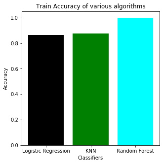

```python
print("Accuracy Comparision for TRAIN data for all the models:\n\n")
plt.subplots(figsize=(5,5))
plt.bar(labels,train_accu,color=['black','green','cyan'])
plt.xlabel('Classifiers')
plt.ylabel('Accuracy')
plt.title('Train Accuracy of various algorithms')
```

```
Accuracy Comparision for TEST data for all the models:
```

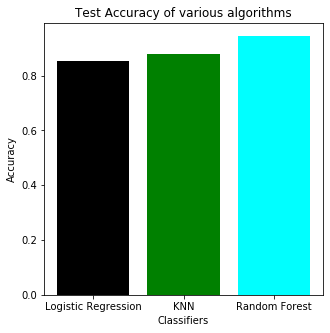

```python
print("Accuracy Comparision for TEST data for all the models:\n\n")
plt.subplots(figsize=(5,5))
plt.bar(labels,test_accu,color=['black','green','cyan'])
plt.xlabel('Classifiers')
plt.ylabel('Accuracy')
plt.title('Test Accuracy of various algorithms')
```

### Here, as we can see out of all the three algorithms the maximum accuracy is obtained using RANDOM FOREST Classifier. Hence, we can conlude by our experiments that Random Forest approach towards Churn Prediction problem is best algorithm.